# **Building Explanations in Natural Language**

```
INFERENCE AS WE WERE DOING PREVIOUSLY

For instance 320:
	Features: Color = 22.0; Bitterness = 25.0; Strength = 0.045; Class = 7.0
	Real output class ---> 7 (Porter)
	Inferred class ---> 7.0(Porter)
	Correct inference!
RULEBASE:
  RULE 1: rule6 - (1.0) IF Color IS (Amber) OR (Brown) AND Strength IS (Session) OR (Standard) THEN Class IS Porter [weight=1.0]

Graphical view of rule6 - (1.0) IF Color IS (Amber) OR (Brown) AND Strength IS (Session) OR (Standard) THEN Class IS Porter [weight=1.0]
```

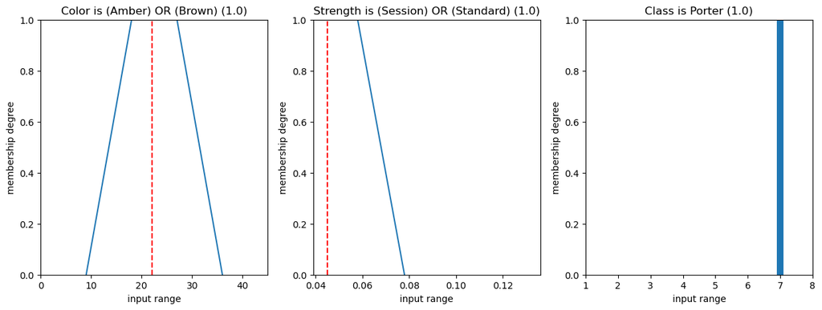

```
INFERENCE AND EXPLANATION BY FCFEXPGEN

Test instance features:
[('Color', 22.0), ('Bitterness', 25.0), ('Strength', 0.045), ('Class', 7.0)]
True class: Porter
Predicted class: Porter

Factual explanation:

The test instance is of class porter because color is (amber) or (brown) and strength is (session) or (standard).

Counterfactual explanations:

The test instance would be of class blanche if color were pale and bitterness were low.
The test instance would be of class lager if color were straw, bitterness were low and strength were standard.
The test instance would be of class pilsner if color were pale and bitterness were high.
The test instance would be of class ipa if color were straw or amber and strength were high.
The test instance would be of class stout if color were black.
The test instance would be of class barleywine if color were straw or amber and strength were very high.
The test instance would be of class belgian-strong-ale if color were brown and strength were high or very high.
```

```python
## this code is developed by Jose Maria Alonso-Moral and Pablo Miguel Perez-Ferreiro

# ID of the dataset instance we'll predict for
ins_id= 320

# The FCFEXPGEN library will need this
values = []
names = []

# We collect the FIS variables and set their values to those of the dataset instance, also we store them for the library call (later)
vars = beer_RP_FDTP_S.getVariables()
for v in vars:
    names.append(v.getName())
    values.append(float(beer_data.get(v.getName())[ins_id]))
    v.setValue(float(beer_data.get(v.getName())[ins_id]))

# Evaluate the rule base
beer_RP_FDTP_S.evaluate()
# Get the inference results and the real class
beerClass = beer_RP_FDTP_S.getVariable(beer_out_target)
trueClass = beer_data.get(beer_out_target)[ins_id]

# Plot the inference process as we were doing previously...
print("INFERENCE AS WE WERE DOING PREVIOUSLY\n")
print(f'For instance {ins_id}:')
print(f'\tFeatures: {"; ".join(var.getName() + " = " + str(var.getValue()) for var in vars)}')
print(f'\tReal output class ---> {str(trueClass)} ({beer_class_names[round(trueClass) - 1]})')
print(f'\tInferred class ---> {str(beerClass.getValue())}({beer_class_names[round(beerClass.getValue()) - 1]})')
print(f'\t{"Correct inference!" if round(float(trueClass)) == round(float(beerClass.getValue())) else "Incorrect inference!"}')
plot_fuzzy_rules(beer_RP_FDTP_S, True)

# And now the verbal explanations coming from FCFEXPGEN!
print("\nINFERENCE AND EXPLANATION BY FCFEXPGEN\n")
generate_counterfactuals(values, names, true_class=str(float(trueClass)),
                         xml_filename=beer_RP_FDTP_S_jfml_str_xml, json_filename="testlib/BEER/BEER.json", linguistic_terms_known=True)
```

#### Exercise I2.5

You have, just above, a complete, comprehensive example on how to define, import and predict/explain for a given problem. Now, using the [GUAJE online tool](https://guaje-online.app.citius.gal/), for which your teachers should have given you access instructions (see the beginning of this notebook), create your own FIS for the PIMA dataset you employed on the previous practical session (you don't need to download it, Online GUAJE already has it pre-loaded). Integrate it into your workspace, and then repeat the task above with it to generate some explanations. Would you prefer this alternative to the SHAP/Visual approaches we used on the previous practical? Why?

**Note:** While we're asking you to compare this new approach with the previous ones, that does not mean you need to repeat any task already done on I1 on this notebook. Just general commentary is enough.

```python
import glob
from pathlib import Path

# Load PIMA Dataset
PIMA_DIR = Path("testlib/PIMA")
PIMA_TXT = PIMA_DIR / "PIMA.txt"

def load_pima_txt(path: Path) -> pd.DataFrame:
    with open(path, "r", encoding="utf-8") as f:
        first = f.readline().strip()

    if first.startswith("VariableNames="):
        # Parse column names from the first line
        cols = first.split("=", 1)[1].split(",")
        cols = [c.strip() for c in cols]

        # Read remaining lines as data
        df = pd.read_csv(path, skiprows=1, header=None, names=cols)
    else:
        # Fallback for standard CSV/TXT
        df = pd.read_csv(path, sep=None, engine="python")
        df.columns = [str(c).strip() for c in df.columns]

    # Ensure clean column names
    df.columns = [c.strip() for c in df.columns]
    return df

pima_df = load_pima_txt(PIMA_TXT)

# Target column
TARGET_COL = "Diabetes"
if TARGET_COL not in pima_df.columns:
    raise KeyError(f"Target column '{TARGET_COL}' not found. Columns: {list(pima_df.columns)}")

# FIS mappings / features
name_mapping = {
    "Number of times pregnant": "PREG",
    "Plasma glucose concentration": "GLU",
    "Two hour serum insulin": "INS",
    "Body mass index": "BMI",
    "Diabetes pedigree function": "DPF",
    "Age": "AGE",
    "Diabetes": "OUT"
}

pima_features_long = [
    "Number of times pregnant",
    "Plasma glucose concentration",
    "Two hour serum insulin",
    "Body mass index",
    "Diabetes pedigree function",
    "Age"
]


# Output threshold
THRESH = 1.5

def y_true_binary(y):
    # 2=positive, 1=negative
    y = int(y)
    if y in (1, 2):
        return 1 if y == 2 else 0
    # fallback
    return 1 if y > 0 else 0


# Load all folds
FOLDS_DIR = Path("folds_pima/")
fold_files = sorted(glob.glob(str(FOLDS_DIR / "CV_*_PIMA.jfml.xml")))

if not fold_files:
    raise FileNotFoundError(f"No fold XMLs found in {FOLDS_DIR}. Expected: CV_*_PIMA.jfml.xml")



def load_and_prepare_fis_for_plot(fis_filename):
    fis = Py4jfml.load(fis_filename)

    # Rename variables to acronyms for readable rules/plots
    for long_name, short_name in name_mapping.items():
        var = fis.getVariable(long_name)
        if var is not None:
            var.setName(short_name)

    # Shorten linguistic labels
    for var_acronym in name_mapping.values():
        var = fis.getVariable(var_acronym)
        if var is not None:
            for term in var.getTerms():
                old = term.getName()
                new = (old.replace("more or less", "~")
                          .replace("average", "Avg")
                          .replace("very", "++")
                          .replace("(", "").replace(")", "")
                          .strip())
                term.setName(new)

    return fis


# Predict a single row
def predict_row_binary(fis_prepared, row):
    # Set inputs (FIS variables are acronyms)
    for feat_long in pima_features_long:
        acronym = name_mapping[feat_long]
        var = fis_prepared.getVariable(acronym)
        if var is not None:
            var.setValue(float(row[feat_long]))

    fis_prepared.evaluate()

    out_var = fis_prepared.getVariable("OUT")
    if out_var is None:
        out_var = fis_prepared.getVariables()[-1]  # fallback

    out_val = float(out_var.getValue())
    y_pred = 1 if out_val > THRESH else 0
    return y_pred, out_val


# Evaluate each fold
def evaluate_fold(fis_path, df):
    fold_name = os.path.basename(fis_path)
    fis = load_and_prepare_fis_for_plot(fis_path)

    y_true_list = [y_true_binary(y) for y in df[TARGET_COL].tolist()]
    y_pred_list = []

    for _, row in df.iterrows():
        yp, _ = predict_row_binary(fis, row)
        y_pred_list.append(yp)

    cm = confusion_matrix(y_true_list, y_pred_list, labels=[0, 1])
    tn, fp, fn, tp = cm.ravel()

    print(f"\n=== {fold_name} ===")
    print("Confusion matrix [[TN, FP], [FN, TP]]:")
    print(cm)
    print(f"TN={tn}, FP={fp}, FN={fn}, TP={tp}")

    print("\nClassification report:")
    print(classification_report(
        y_true_list, y_pred_list,
        target_names=["Healthy (0)", "Diabetes (1)"],
        digits=4
    ))

    return cm


cms = []

for fis_path in fold_files:
    cm = evaluate_fold(fis_path, pima_df)
    cms.append(cm)

cm_sum = np.sum(cms, axis=0)
tn, fp, fn, tp = cm_sum.ravel()

print("\n==============================")
print("Aggregated across folds (sum)")
print("==============================")
print("Sum confusion matrix [[TN, FP], [FN, TP]]:")
print(cm_sum)
print(f"SUM TN={tn}, FP={fp}, FN={fn}, TP={tp}")
```

```
=== CV_0_PIMA.jfml.xml ===
Confusion matrix [[TN, FP], [FN, TP]]:
[[470  30]
 [157 111]]
TN=470, FP=30, FN=157, TP=111

Classification report:
              precision    recall  f1-score   support

 Healthy (0)     0.7496    0.9400    0.8341       500
Diabetes (1)     0.7872    0.4142    0.5428       268

    accuracy                         0.7565       768
   macro avg     0.7684    0.6771    0.6884       768
weighted avg     0.7627    0.7565    0.7324       768


=== CV_1_PIMA.jfml.xml ===
Confusion matrix [[TN, FP], [FN, TP]]:
[[437  63]
 [116 152]]
TN=437, FP=63, FN=116, TP=152

Classification report:
              precision    recall  f1-score   support

 Healthy (0)     0.7902    0.8740    0.8300       500
Diabetes (1)     0.7070    0.5672    0.6294       268

    accuracy                         0.7669       768
   macro avg     0.7486    0.7206    0.7297       768
weighted avg     0.7612    0.7669    0.7600       768


=== CV_2_PIMA.jfml.xml ===
Confusion matrix [[TN, FP], [FN, TP]]:
[[443  57]
 [116 152]]
TN=443, FP=57, FN=116, TP=152

```

[output cut: 37 more lines]

```
 Healthy (0)     0.7729    0.9120    0.8367       500
Diabetes (1)     0.7528    0.5000    0.6009       268

    accuracy                         0.7682       768
   macro avg     0.7628    0.7060    0.7188       768
weighted avg     0.7659    0.7682    0.7544       768


==============================
Aggregated across folds (sum)
==============================
Sum confusion matrix [[TN, FP], [FN, TP]]:
[[2262  238]
 [ 682  658]]
SUM TN=2262, FP=238, FN=682, TP=658
```

```
============================================================
EXPLANATION — Fold: CV_0_PIMA.jfml.xml | Row: 0
============================================================
Inputs:
 - Number of times pregnant: 6.0
 - Plasma glucose concentration: 148.0
 - Two hour serum insulin: 0.0
 - Body mass index: 33.6
 - Diabetes pedigree function: 0.627
 - Age: 50.0

True label: 1 -> Diabetes
Predicted:  1 -> Diabetes
Raw OUT value: 2.0000 (threshold=1.5)

----- Visual explanation (active rules) -----
RULEBASE:
  RULE 1: rule1 - (0.025125628) IF GLU IS ++ low OR low OR Avg THEN OUT IS 1.0 [weight=1.0]
  RULE 2: rule3 - (0.061538488) IF GLU IS high AND BMI IS ~ ~ Avg AND DPF IS ++ low AND AGE IS low THEN OUT IS 1.0 [weight=1.0]
  RULE 3: rule7 - (0.93846154) IF GLU IS high AND DPF IS low AND AGE IS low OR Avg THEN OUT IS 2.0 [weight=1.0]
  RULE 4: rule8 - (0.00298058) IF GLU IS high AND BMI IS high OR ++ high AND AGE IS low THEN OUT IS 2.0 [weight=1.0]

Graphical view of rule1 - (0.025125628) IF GLU IS ++ low OR low OR Avg THEN OUT IS 1.0 [weight=1.0]
```

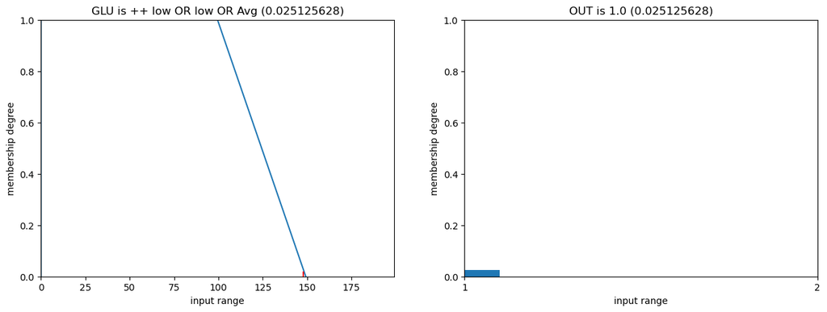

```
Graphical view of rule3 - (0.061538488) IF GLU IS high AND BMI IS ~ ~ Avg AND DPF IS ++ low AND AGE IS low THEN OUT IS 1.0 [weight=1.0]
```

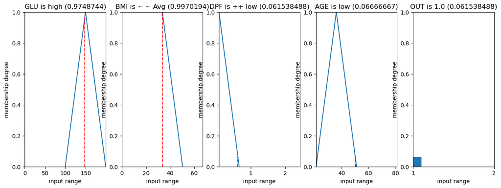

```
Graphical view of rule7 - (0.93846154) IF GLU IS high AND DPF IS low AND AGE IS low OR Avg THEN OUT IS 2.0 [weight=1.0]
```

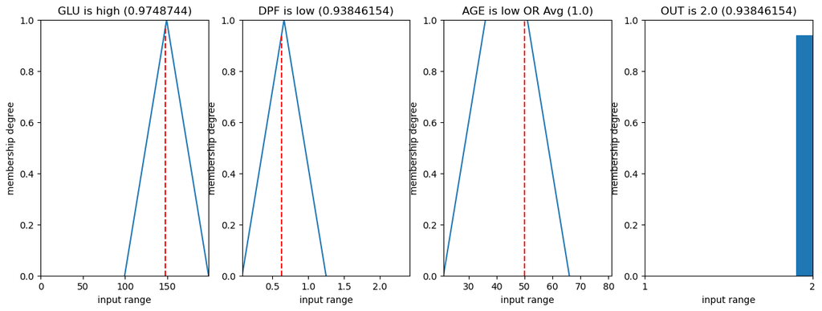

```
Graphical view of rule8 - (0.00298058) IF GLU IS high AND BMI IS high OR ++ high AND AGE IS low THEN OUT IS 2.0 [weight=1.0]
```

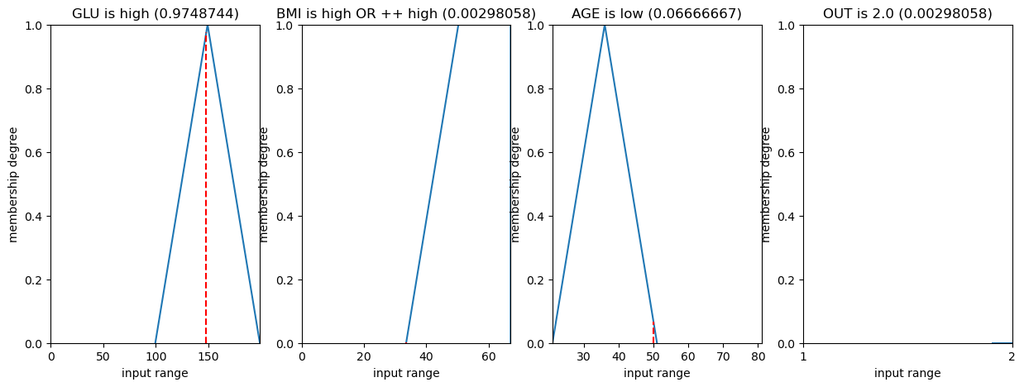

```python
# Visual explanation (active rules)
inspect_fold_idx = 0   # fold to inspect
inspect_row_idx = 0    # row/patient to explain

fis_path = fold_files[inspect_fold_idx]
fis_plot = load_and_prepare_fis_for_plot(fis_path)
row = pima_df.iloc[inspect_row_idx]

y_pred, out_val = predict_row_binary(fis_plot, row)
y_true = y_true_binary(row[TARGET_COL])

print("\n" + "="*60)
print(f"EXPLANATION — Fold: {os.path.basename(fis_path)} | Row: {inspect_row_idx}")
print("="*60)
print("Inputs:")
for feat_long in pima_features_long:
    print(f" - {feat_long}: {float(row[feat_long])}")
print(f"\nTrue label: {y_true} -> {'Diabetes' if y_true==1 else 'Healthy'}")
print(f"Predicted:  {y_pred} -> {'Diabetes' if y_pred==1 else 'Healthy'}")
print(f"Raw OUT value: {out_val:.4f} (threshold={THRESH})")

print("\n----- Visual explanation (active rules) -----")
plt.rcParams['figure.figsize'] = [20, 10]
plot_fuzzy_rules(fis_plot, True)
plt.show()
```

We evaluated the five FIS models generated by GUAJE (one per CV fold) by computing a confusion matrix and standard classification metrics for each exported system. Across folds, overall accuracy stays in a fairly narrow band (≈0.736–0.775), which suggests the learned rule bases are reasonably stable with respect to the training split.

A clear pattern appears when we look at class-wise behaviour. The systems are consistently much better at recognising the “Healthy” class than the “Diabetes” class: in every fold, the recall for Healthy is high (≈0.87–0.94), while the recall for Diabetes is noticeably lower (≈0.41–0.57). This means the models tend to avoid false positives (moderate FP counts) but at the cost of producing many false negatives (missed diabetes cases). The aggregated confusion matrix confirms this conservative tendency: TN=2262 and FP=238 versus FN=682 and TP=658, i.e., the models more often label borderline cases as Healthy than as Diabetes.

Overall, these results indicate that our FIS provides a solid interpretable baseline with decent accuracy, but it behaves like a conservative detector (high specificity, moderate sensitivity). If the intended use is screening (where missing positives is costly), we would likely want to reduce FN—e.g., by adjusting the decision threshold, using more expressive partitions/labels, or biasing training toward the positive class. Regardless, the main advantage of this approach is that every prediction can be traced back to fired rules and complemented with factual/counterfactual explanations, which is harder to achieve with purely post-hoc explainers.

Regarding whether we would prefer this alternative to the SHAP/visual approaches from the previous practical, we would not see it as a strict replacement but as a choice driven by the application requirements. We would prefer the FIS when interpretability and auditability are the main priority, because the model is transparent by design and explanations follow directly from the rule base (including actionable counterfactuals such as “if GLU moved from High to Medium, the predicted class would change”). However, we would prefer SHAP/visual methods when predictive performance is the priority and we want to keep a stronger black-box model while still obtaining local/global feature attributions. In our case, the FIS shows a tendency to produce many false negatives, so for high-stakes screening we would likely rely on a more accurate model and use SHAP/visual explanations, whereas for transparent decision policies and human-verifiable logic we would choose the FIS-based approach.

### Global and Counterfactual Explanations on a Complex Model

In the previous sections, we evaluated our Mamdani Fuzzy Inference System using a 5-fold Cross-Validation approach to ensure the robustness and generalization of our model. We also applied a simplification process to reduce the number of rules and features.

To fully explore the capabilities of eXplainable AI (XAI) and linguistic generation, we have generated a new, unsimplified model in GUAJE (`PIMA.jfml.xml`) without Cross-Validation. This allows us to:

1. **Analyze the Global Knowledge Base:** Inspect the complete set of rules generated by the expert system using all available features.
2. **Generate Natural Language Explanations:** Utilize the `FCFEXPGEN` library, alongside a JSON metadata file (`PIMA.txt.json`), to translate the fuzzy inference process into human-readable text.
3. **Extract Counterfactuals:** Provide a "what-if" scenario for a specific patient, detailing exactly which features would need to change for the system to output a healthy diagnosis instead of a diabetic one.

In the following cell, we will load this complex model, extract its global rule base, evaluate it for **Patient 0**, and print the Factual and Counterfactual explanations.

```
==================================================
 GLOBAL EXPLANATION (COMPLEX KNOWLEDGE BASE)
==================================================

FUZZY SYSTEM: PIMA.txt - MAMDANI
KNOWLEDGEBASE:
  *Number of times pregnant - domain[0.0, 17.0] - input
	Low -  trapezoid [a: 0.0, b: 0.0, c: 0.0, d: 4.25]
	Medium -  triangular [a: 0.0, b: 4.25, c: 8.5]
	High -  triangular [a: 4.25, b: 8.5, c: 12.75]
	Label 4 -  triangular [a: 8.5, b: 12.75, c: 17.0]
	Label 5 -  trapezoid [a: 12.75, b: 17.0, c: 17.0, d: 17.0]

  *Plasma glucose concentration - domain[0.0, 199.0] - input
	Low -  trapezoid [a: 0.0, b: 0.0, c: 0.0, d: 49.75]
	Medium -  triangular [a: 0.0, b: 49.75, c: 99.5]
	High -  triangular [a: 49.75, b: 99.5, c: 149.25]
	Label 4 -  triangular [a: 99.5, b: 149.25, c: 199.0]
	Label 5 -  trapezoid [a: 149.25, b: 199.0, c: 199.0, d: 199.0]

  *Diastolic blood pressure - domain[0.0, 122.0] - input
	Low -  trapezoid [a: 0.0, b: 0.0, c: 0.0, d: 30.5]
	Medium -  triangular [a: 0.0, b: 30.5, c: 61.0]
	High -  triangular [a: 30.5, b: 61.0, c: 91.5]
	Label 4 -  triangular [a: 61.0, b: 91.5, c: 122.0]
	Label 5 -  trapezoid [a: 91.5, b: 122.0, c: 122.0, d: 122.0]

  *Triceps skin fold thickness - domain[0.0, 99.0] - input
	Low -  trapezoid [a: 0.0, b: 0.0, c: 0.0, d: 24.75]
	Medium -  triangular [a: 0.0, b: 24.75, c: 49.5]
	High -  triangular [a: 24.75, b: 49.5, c: 74.25]
	Label 4 -  triangular [a: 49.5, b: 74.25, c: 99.0]
	Label 5 -  trapezoid [a: 74.25, b: 99.0, c: 99.0, d: 99.0]

  *Two hour serum insulin - domain[0.0, 846.0] - input
	Low -  trapezoid [a: 0.0, b: 0.0, c: 0.0, d: 211.5]
	Medium -  triangular [a: 0.0, b: 211.5, c: 423.0]
	High -  triangular [a: 211.5, b: 423.0, c: 634.5]
	Label 4 -  triangular [a: 423.0, b: 634.5, c: 846.0]
	Label 5 -  trapezoid [a: 634.5, b: 846.0, c: 846.0, d: 846.0]
```

[output cut: 41 more lines]

```


INFERENCE AS WE WERE DOING PREVIOUSLY

For instance 0:
	Features: Number of times pregnant = 6.0; Plasma glucose concentration = 148.0; Diastolic blood pressure = 72.0; Triceps skin fold thickness = 35.0; Two hour serum insulin = 0.0; Body mass index = 33.6; Diabetes pedigree function = 0.627; Age = 50.0
	Real output class ---> 2.0
	Inferred class ---> 2.0
	Correct inference!
RULEBASE:
  RULE 1: rule3 - (0.025125628) IF Plasma glucose concentration IS High THEN Output IS tested negative [weight=1.0]
  RULE 2: rule9 - (0.06666667) IF Plasma glucose concentration IS Label 4 AND Age IS Middle-aged THEN Output IS tested positive [weight=1.0]
  RULE 3: rule10 - (0.93333334) IF Plasma glucose concentration IS Label 4 AND Age IS Old THEN Output IS tested positive [weight=1.0]

Graphical view of rule3 - (0.025125628) IF Plasma glucose concentration IS High THEN Output IS tested negative [weight=1.0]
```

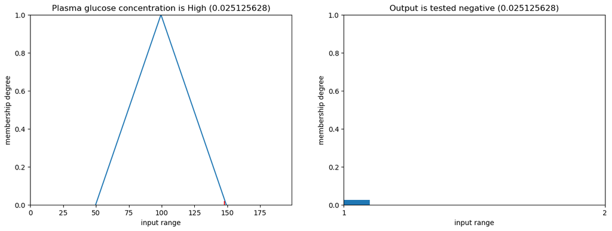

```
Graphical view of rule9 - (0.06666667) IF Plasma glucose concentration IS Label 4 AND Age IS Middle-aged THEN Output IS tested positive [weight=1.0]
```

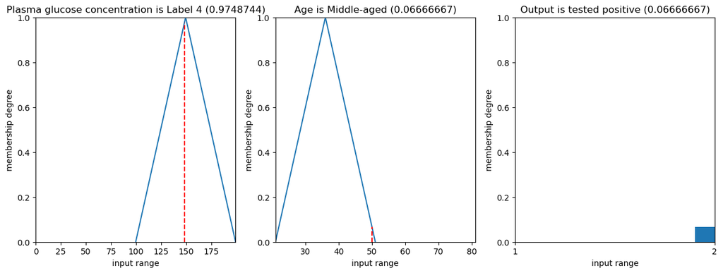

```
Graphical view of rule10 - (0.93333334) IF Plasma glucose concentration IS Label 4 AND Age IS Old THEN Output IS tested positive [weight=1.0]
```

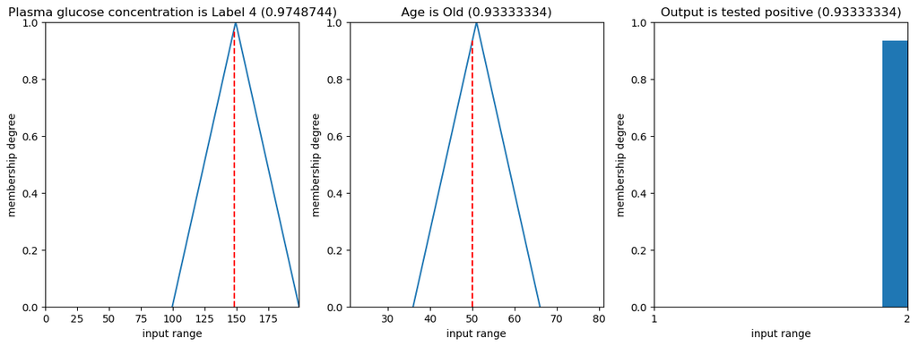

```
INFERENCE AND EXPLANATION BY FCFEXPGEN

Test instance features:
[('Number of times pregnant', 6.0), ('Plasma glucose concentration', 148.0), ('Diastolic blood pressure', 72.0), ('Triceps skin fold thickness', 35.0), ('Two hour serum insulin', 0.0), ('Body mass index', 33.6), ('Diabetes pedigree function', 0.627), ('Age', 50.0), ('Output', 2.0)]
True class: tested positive
Predicted class: tested positive

Factual explanation:

The test instance is of class tested positive because plasma glucose concentration is label 4 and age is old.

Counterfactual explanations:

The test instance would be of class tested negative if body mass index were high and age were young.
```

```python
# --- EXERCISE: COMPLEX MODEL (GLOBAL & COUNTERFACTUAL EXPLANATIONS) ---
import os
import matplotlib.pyplot as plt
from pathlib import Path

# 1. File names configuration
PIMA_DIR = Path("testlib/PIMA")

fis_filename = str(Path("PIMA.jfml.xml").resolve())
json_filename = str((PIMA_DIR / "PIMA.txt.json").resolve())

target_col_dataset = "Diabetes" # Real name in the PIMA dataset
target_col_fis = "Output"       # Name in the new GUAJE model

if not os.path.exists(fis_filename) or not os.path.exists(json_filename):
    print(f"Error: Make sure '{fis_filename}' and '{json_filename}' are in the correct directory.")
else:
    # 2. Load the complex FIS
    pima_complex_fis = Py4jfml.load(fis_filename)

    # ==========================================================
    # GLOBAL EXPLANATION
    # ==========================================================
    print("==================================================")
    print(" GLOBAL EXPLANATION (COMPLEX KNOWLEDGE BASE)")
    print("==================================================")
    print(pima_complex_fis)

    # ==========================================================
    # PATIENT PREPARATION (Local Explanation)
    # ==========================================================
    ins_id = 0  # Target instance ID

    values = []
    names = []

    # Collect variables and assign values from pima_df
    vars = pima_complex_fis.getVariables()
    for v in vars:
        var_name = v.getName()
        names.append(var_name)

        # Map 'Output' back to 'Diabetes' to find it in the dataframe
        df_col_name = target_col_dataset if var_name == target_col_fis else var_name

        # Get the value for the specific row from the DataFrame
        val = float(pima_df.iloc[ins_id][df_col_name])
        values.append(val)
        v.setValue(val)

    # 3. Evaluate the system
    pima_complex_fis.evaluate()

    # Get the inference result and the true class
    out_var = pima_complex_fis.getVariable(target_col_fis)
    if out_var is None: out_var = pima_complex_fis.getVariables()[-1]

    trueClass = pima_df.iloc[ins_id][target_col_dataset]

    # ==========================================================
    # LOCAL EXPLANATION (Plotting)
    # ==========================================================
    print("\nINFERENCE AS WE WERE DOING PREVIOUSLY\n")
    print(f'For instance {ins_id}:')

    features_str = "; ".join(f"{var.getName()} = {var.getValue()}" for var in vars if var.getName() != target_col_fis)
    print(f'\tFeatures: {features_str}')
    print(f'\tReal output class ---> {str(trueClass)}')
    print(f'\tInferred class ---> {str(out_var.getValue())}')

    if round(float(trueClass)) == round(float(out_var.getValue())):
        print("\tCorrect inference!")
    else:
        print("\tIncorrect inference!")

    # Plot active rules
    plt.rcParams['figure.figsize'] = [20, 10]
    plot_fuzzy_rules(pima_complex_fis, True)
    plt.show()

    # ==========================================================
    # COUNTERFACTUAL EXPLANATIONS (FCFEXPGEN)
    # ==========================================================
    print("\nINFERENCE AND EXPLANATION BY FCFEXPGEN\n")

    try:
        # Use the already resolved absolute paths for the backend files
        generate_counterfactuals(
            values,
            names,
            true_class=str(float(trueClass)),
            xml_filename=fis_filename,
            json_filename=json_filename,
            linguistic_terms_known=True
        )
    except Exception as e:
        print(f"Error generating counterfactuals: {e}")
```

### Analysis of the Results and Final Conclusion

The execution of the complex model provides profound insights into the inner workings of our Fuzzy System, fulfilling the core principles of Explainable AI (XAI):

**1. Global Interpretation:** Unlike opaque "black-box" models, printing our Knowledge Base reveals exactly 13 understandable rules. We can easily verify the medical logic learned by the system, such as *Rule 1*, which logically dictates that a low plasma glucose concentration strongly points toward a negative diabetes test.

**2. Factual Explanation:** For our specific test instance (Patient 0), the system correctly predicted a positive diabetes diagnosis. Through the natural language generation capabilities of `FCFEXPGEN`, the system explicitly states the main driving factors:

> *"The test instance is of class tested positive because plasma glucose concentration is label 4 and age is old."*

This matches the graphical output, where Rule 10 (which ties high glucose and older age to a positive diagnosis) heavily dominates the inference process with an activation weight of 0.93.

**3. Counterfactual Explanation:** Counterfactuals help us understand the decision boundaries of the model by showing what it would take to flip the prediction. The system generated the following alternative scenario:

> *"The test instance would be of class tested negative if body mass index were high and age were young."*

This highlights that for this specific fuzzy model, Age is a critical risk factor. The model suggests that if this exact same patient had been significantly younger (shifting the fuzzy membership to "young"), the risk assessment would have dropped below the positive threshold, even with a relatively high BMI.